# EDA_&_MACHINE_LEARNING_Week_3

## **Continuation of task - 1**

## **DATA CLEANING AND EDA** - **TASK - 1**

**Use case:** You are the junior data scientist in a large team. Your responsibilities include preprocessing all of the data and presenting the modeling team with a dataset suitable for the model they will create. You have absolute freedom to transform the data, however you must have good reasons and you should communicate them.

**Perform EDA** and initial Cleaning on the dataset provided. Justify all choices and produce a document to be handed over to the modeling team that includes all plots, charts and deletions. Include a one paragraph description of your cleaned dataset and present findings to the modeling team.

**Deliverables:** public github or gitlab link with the code for this assignment(optional for now) CSV with the clean Data copy of code in HTML or Text format.

**Make a Short presentation**of your work, using any slideshow software Presentation backup version in PDF format

**Project Summary:** One paragraphs description of the work done. At least 7 bullet points on specific actions and technologies. For example: - Utilized Python and Pandas Library to construct a DataFrame for data processing.

## **Mount the Google drive to Colab**

```python
from google.colab import drive
drive.mount('/content/drive/')
```

# **Importing Libraries**

```python
import pandas as pd
import numpy as np
import matplotlib.pyplot as plt
import seaborn as sns
```

## **Load the dataset**

```python
df = pd.read_csv("/content/drive/MyDrive/Dataset/raw_house_data.csv")
df
```

|  | MLS | sold_price | zipcode | longitude | latitude | lot_acres | taxes | year_built | bedrooms | bathrooms | sqrt_ft | garage | kitchen_features | fireplaces | floor_covering | HOA |
| --- | --- | --- | --- | --- | --- | --- | --- | --- | --- | --- | --- | --- | --- | --- | --- | --- |
| 0 | 21530491 | 5300000.0 | 85637 | -110.378200 | 31.356362 | 2154.00 | 5272.00 | 1941 | 13 | 10.0 | 10500.0 | 0.0 | Dishwasher, Freezer, Refrigerator, Oven | 6 | Mexican Tile, Wood | 0 |
| 1 | 21529082 | 4200000.0 | 85646 | -111.045371 | 31.594213 | 1707.00 | 10422.36 | 1997 | 2 | 2.0 | 7300.0 | 0.0 | Dishwasher, Garbage Disposal | 5 | Natural Stone, Other | 0 |
| 2 | 3054672 | 4200000.0 | 85646 | -111.040707 | 31.594844 | 1707.00 | 10482.00 | 1997 | 2 | 3.0 | NaN | NaN | Dishwasher, Garbage Disposal, Refrigerator | 5 | Natural Stone, Other: Rock | NaN |
| 3 | 21919321 | 4500000.0 | 85646 | -111.035925 | 31.645878 | 636.67 | 8418.58 | 1930 | 7 | 5.0 | 9019.0 | 4.0 | Dishwasher, Double Sink, Pantry: Butler, Refri... | 4 | Ceramic Tile, Laminate, Wood | NaN |
| 4 | 21306357 | 3411450.0 | 85750 | -110.813768 | 32.285162 | 3.21 | 15393.00 | 1995 | 4 | 6.0 | 6396.0 | 3.0 | Dishwasher, Garbage Disposal, Refrigerator, Mi... | 5 | Carpet, Concrete | 55 |
| ... | ... | ... | ... | ... | ... | ... | ... | ... | ... | ... | ... | ... | ... | ... | ... | ... |
| 4995 | 21810382 | 495000.0 | 85641 | -110.661829 | 31.907917 | 4.98 | 2017.00 | 2005 | 5 | 3.0 | 3601.0 | 3.0 | Dishwasher, Double Sink, Garbage Disposal, Gas... | 1 | Carpet, Ceramic Tile | NaN |
| 4996 | 21908591 | 550000.0 | 85750 | -110.858556 | 32.316373 | 1.42 | 4822.01 | 1990 | 4 | 3.0 | 2318.0 | 3.0 | Dishwasher, Double Sink, Electric Range, Garba... | 1 | Carpet, Ceramic Tile | 43 |
| 4997 | 21832452 | 475000.0 | 85192 | -110.755428 | 32.964708 | 12.06 | 1000.00 | 1969 | 3 | 2.0 | 1772.0 | 0.0 | Dishwasher, Electric Range, Island, Refrigerat... | 0 | Ceramic Tile | NaN |
| 4998 | 21900515 | 550000.0 | 85745 | -111.055528 | 32.296871 | 1.01 | 5822.93 | 2009 | 4 | 4.0 | 3724.0 | 3.0 | Dishwasher, Double Sink, Garbage Disposal, Gas... | 1 | Carpet, Ceramic Tile | NaN |
| 4999 | 4111490 | 450000.0 | 85621 | -110.913054 | 31.385259 | 4.16 | 2814.48 | 1988 | 4 | 4.0 | 4317.0 | NaN | Compactor, Dishwasher, Double Sink, Island, Ap... | 3 | Carpet, Mexican Tile | NaN |

5000 rows × 16 columns

```python
from google.colab import drive
drive.mount('/content/drive')
```

## **Column Explanation**

```python
df.columns
```

```
Index(['MLS', 'sold_price', 'zipcode', 'longitude', 'latitude', 'lot_acres',
       'taxes', 'year_built', 'bedrooms', 'bathrooms', 'sqrt_ft', 'garage',
       'kitchen_features', 'fireplaces', 'floor_covering', 'HOA'],
      dtype='object')
```

- **MLS** : Multiple Listing Service number, a unique identifier to each property listing
- **sold_price** : The final proce of the property is USD
- **zipcode** : The postal code where the property is located
- **longitude** : The geographic longitude coordnates of the property
- **latitude** : The geographic latitude coordnates of the property
- **lot_acres** : The size of the property lot in acres
- **taxes** : The annual property tax amount in USA
- **year_built** : The year the property was constructed
- **bedrooms** : The number of bedrooms in the property
- **bathrooms** : The number of bathrooms in the property
- **sqrt_ft** : The square foot of the property
- **garage** : The number of garage spaces
- **kitchen_features** : A list of features available in the kitchen
- **fireplaces** : The number of fireplaces in the property
- **floor_covering** : The types of flooring materials used in the property
- **HOA** : Homeowners Association fee

# **Initial Data Exploration**

```python
df.head()
```

|  | MLS | sold_price | zipcode | longitude | latitude | lot_acres | taxes | year_built | bedrooms | bathrooms | sqrt_ft | garage | kitchen_features | fireplaces | floor_covering | HOA |
| --- | --- | --- | --- | --- | --- | --- | --- | --- | --- | --- | --- | --- | --- | --- | --- | --- |
| 0 | 21530491 | 5300000.0 | 85637 | -110.378200 | 31.356362 | 2154.00 | 5272.00 | 1941 | 13 | 10.0 | 10500.0 | 0.0 | Dishwasher, Freezer, Refrigerator, Oven | 6 | Mexican Tile, Wood | 0 |
| 1 | 21529082 | 4200000.0 | 85646 | -111.045371 | 31.594213 | 1707.00 | 10422.36 | 1997 | 2 | 2.0 | 7300.0 | 0.0 | Dishwasher, Garbage Disposal | 5 | Natural Stone, Other | 0 |
| 2 | 3054672 | 4200000.0 | 85646 | -111.040707 | 31.594844 | 1707.00 | 10482.00 | 1997 | 2 | 3.0 | NaN | NaN | Dishwasher, Garbage Disposal, Refrigerator | 5 | Natural Stone, Other: Rock | NaN |
| 3 | 21919321 | 4500000.0 | 85646 | -111.035925 | 31.645878 | 636.67 | 8418.58 | 1930 | 7 | 5.0 | 9019.0 | 4.0 | Dishwasher, Double Sink, Pantry: Butler, Refri... | 4 | Ceramic Tile, Laminate, Wood | NaN |
| 4 | 21306357 | 3411450.0 | 85750 | -110.813768 | 32.285162 | 3.21 | 15393.00 | 1995 | 4 | 6.0 | 6396.0 | 3.0 | Dishwasher, Garbage Disposal, Refrigerator, Mi... | 5 | Carpet, Concrete | 55 |

```python
df.tail()
```

|  | MLS | sold_price | zipcode | longitude | latitude | lot_acres | taxes | year_built | bedrooms | bathrooms | sqrt_ft | garage | kitchen_features | fireplaces | floor_covering | HOA |
| --- | --- | --- | --- | --- | --- | --- | --- | --- | --- | --- | --- | --- | --- | --- | --- | --- |
| 4995 | 21810382 | 495000.0 | 85641 | -110.661829 | 31.907917 | 4.98 | 2017.00 | 2005 | 5 | 3.0 | 3601.0 | 3.0 | Dishwasher, Double Sink, Garbage Disposal, Gas... | 1 | Carpet, Ceramic Tile | NaN |
| 4996 | 21908591 | 550000.0 | 85750 | -110.858556 | 32.316373 | 1.42 | 4822.01 | 1990 | 4 | 3.0 | 2318.0 | 3.0 | Dishwasher, Double Sink, Electric Range, Garba... | 1 | Carpet, Ceramic Tile | 43 |
| 4997 | 21832452 | 475000.0 | 85192 | -110.755428 | 32.964708 | 12.06 | 1000.00 | 1969 | 3 | 2.0 | 1772.0 | 0.0 | Dishwasher, Electric Range, Island, Refrigerat... | 0 | Ceramic Tile | NaN |
| 4998 | 21900515 | 550000.0 | 85745 | -111.055528 | 32.296871 | 1.01 | 5822.93 | 2009 | 4 | 4.0 | 3724.0 | 3.0 | Dishwasher, Double Sink, Garbage Disposal, Gas... | 1 | Carpet, Ceramic Tile | NaN |
| 4999 | 4111490 | 450000.0 | 85621 | -110.913054 | 31.385259 | 4.16 | 2814.48 | 1988 | 4 | 4.0 | 4317.0 | NaN | Compactor, Dishwasher, Double Sink, Island, Ap... | 3 | Carpet, Mexican Tile | NaN |

- Here we can observe that there are 5000 rows and 16 columns in the dataframe

```python
# Calculating the rows * columns in the dataframe
print(df.shape)
```

```
(5000, 16)
```

```python
df.info()
```

```
<class 'pandas.core.frame.DataFrame'>
RangeIndex: 5000 entries, 0 to 4999
Data columns (total 16 columns):
 #   Column            Non-Null Count  Dtype
---  ------            --------------  -----
 0   MLS               5000 non-null   int64
 1   sold_price        5000 non-null   float64
 2   zipcode           5000 non-null   int64
 3   longitude         5000 non-null   float64
 4   latitude          5000 non-null   float64
 5   lot_acres         4990 non-null   float64
 6   taxes             5000 non-null   float64
 7   year_built        5000 non-null   int64
 8   bedrooms          5000 non-null   int64
 9   bathrooms         4994 non-null   float64
 10  sqrt_ft           4944 non-null   float64
 11  garage            4993 non-null   float64
 12  kitchen_features  4967 non-null   object
 13  fireplaces        5000 non-null   object
 14  floor_covering    4999 non-null   object
 15  HOA               4438 non-null   object
dtypes: float64(8), int64(4), object(4)
memory usage: 625.1+ KB
```

# Bar plot shows the distribution

- In the below plot we can see the data types across the features

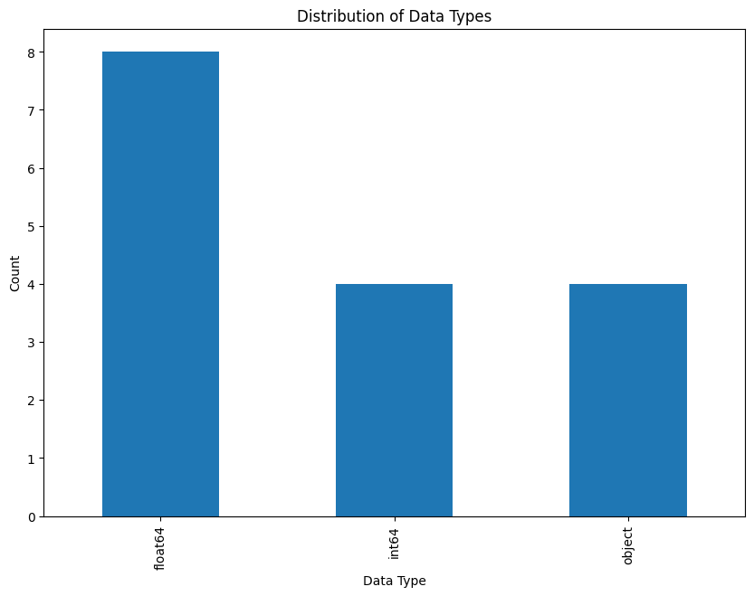

```python
plt.figure(figsize=(10,7))
df.dtypes.value_counts().plot(kind='bar')
plt.title('Distribution of Data Types')
plt.xlabel('Data Type')
plt.ylabel('Count')
plt.show()
```

**Handling Missing Values**

```python
# Missing Values Analysis
missing_values = df.isnull().sum()
missing_values
```

|  | 0 |
| --- | --- |
| MLS | 0 |
| sold_price | 0 |
| zipcode | 0 |
| longitude | 0 |
| latitude | 0 |
| lot_acres | 10 |
| taxes | 0 |
| year_built | 0 |
| bedrooms | 0 |
| bathrooms | 6 |
| sqrt_ft | 56 |
| garage | 7 |
| kitchen_features | 33 |
| fireplaces | 0 |
| floor_covering | 1 |
| HOA | 562 |

**dtype:** int64

- Now, will check the percentage of the missing values in the whole dataframe

```python
missing_percentage = 100 * df.isnull().sum()/len(df)
missing_percentage
```

|  | 0 |
| --- | --- |
| MLS | 0.00 |
| sold_price | 0.00 |
| zipcode | 0.00 |
| longitude | 0.00 |
| latitude | 0.00 |
| lot_acres | 0.20 |
| taxes | 0.00 |
| year_built | 0.00 |
| bedrooms | 0.00 |
| bathrooms | 0.12 |
| sqrt_ft | 1.12 |
| garage | 0.14 |
| kitchen_features | 0.66 |
| fireplaces | 0.00 |
| floor_covering | 0.02 |
| HOA | 11.24 |

**dtype:** float64

```python
# Create a table for the results
missing_data = pd.DataFrame({
    'Missing Values': missing_values,
    'Percentage': missing_percentage})
missing_data = missing_data.sort_values('Percentage', ascending=False)
print(missing_data)
```

```
                  Missing Values  Percentage
HOA                          562       11.24
sqrt_ft                       56        1.12
kitchen_features              33        0.66
lot_acres                     10        0.20
garage                         7        0.14
bathrooms                      6        0.12
floor_covering                 1        0.02
MLS                            0        0.00
sold_price                     0        0.00
zipcode                        0        0.00
longitude                      0        0.00
latitude                       0        0.00
taxes                          0        0.00
year_built                     0        0.00
bedrooms                       0        0.00
fireplaces                     0        0.00
```

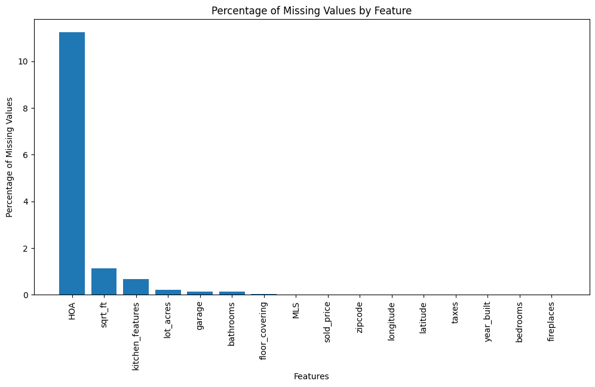

```python
# Bar Plot
plt.figure(figsize=(12,6))
plt.bar(missing_data.index, missing_data['Percentage'])
plt.title('Percentage of Missing Values by Feature')
plt.xlabel('Features')
plt.ylabel('Percentage of Missing Values')
plt.xticks(rotation=90)
plt.show()
```

**MISSING VALUE ANALYSIS**

After analysing the missing values in the dataset, I discovered few hidden patterns in the dataset, which are

**Observations**

1. **HOA (Homeowners Association) Fees**: This feature has the highest percentage of missing values at **11.24% (562 entries)**. This significant amount of missing data could be due to:

```
*    Some properties not being part of an HOA
*    Incomplete data collection for this field
*    HOA information not being available for certain listings
```

2. **sqrt_ft (Square Footage)**: About **1.12% (56 entries)** of the data is missing for this feature. While **not a large percentage**, square footage is typically an **important feature in real estate analysis**, so we should consider how to handle these missing values carefully.
3. **kitchen_features**: **0.66% (33 entries)** of this data is missing. This could be due to **incomplete listings** or properties without notable kitchen features.
4. **Low-level missing data**: Several features (lot_acres, garage, bathrooms, floor_covering) have very low percentages of missing data (**less than 0.2%**). These could potentially be due to data entry errors or truly missing information for a small subset of properties.
5. **Complete data**: Many important features such as MLS, year_built, taxes, List item latitude, longitude, sold_price, zipcode, bedrooms, and fireplaces have no missing values, **which is excellent for our analysis**.

**Implications and Next Steps**

1. **For HOA fees**, given the high percentage of missing values, we should investigate if these are truly missing or if 'HOA' is a valid category. We might consider **filling up** empty cells with **0**.
2. **For sqrt_ft**, given its importance, we might use a more sophisticated imputation method such as **KNN** imputation or **regression** imputation based on other related features.
3. For features with very **low percentages** of missing values, simple imputation methods like **median** or **mode** imputation should suffice.
4. We should investigate if there's any pattern to the missing values - are they missing completely at random (**MCAR**), missing at random (**MAR**), or missing not at random (**MNAR**)? This will inform our imputation strategy.
5. It's encouraging that many key features have **no missing value**s, which will provide a **solid foundation** for **our analysis** and **modeling efforts**.

By addressing these missing values appropriately, we can ensure the integrity and completeness of our dataset for subsequent analysis and modeling stages.

```python
# HOA fees
## Replace missinga values with 0
df.loc[:,'HOA'] = df['HOA'].fillna(0)

# sqrt_ft (Square Footage)
## Use mean imputation based on bedrooms and bathrooms
df['sqrt_ft'] = df.groupby(['bedrooms', 'bathrooms'])['sqrt_ft'].transform(lambda x: x.fillna(x.mean()))
# If any values are still missing, fill with overall mean
df.loc[:, 'sqrt_ft'] = df['sqrt_ft'].fillna(df['sqrt_ft'].mean())

# kitchen_features
## Impute with mode (most frequent value)
df.loc[:, 'kitchen_features'] = df['kitchen_features'].fillna(df['kitchen_features'].mode()[0])

# Low-level missing data
## Impute with median for numerical features and mode for categorical features
df.loc[:, 'lot_acres'] = df['lot_acres'].fillna(df['lot_acres'].median())
df.loc[:, 'garage'] = df['garage'].fillna(df['garage'].median())
df.loc[:, 'bathrooms'] = df['bathrooms'].fillna(df['bathrooms'].median())
df.loc[:, 'floor_covering'] = df['floor_covering'].fillna(df['floor_covering'].mode()[0])
```

```python
df.head()
```

|  | MLS | sold_price | zipcode | longitude | latitude | lot_acres | taxes | year_built | bedrooms | bathrooms | sqrt_ft | garage | kitchen_features | fireplaces | floor_covering | HOA |
| --- | --- | --- | --- | --- | --- | --- | --- | --- | --- | --- | --- | --- | --- | --- | --- | --- |
| 0 | 21530491 | 5300000.0 | 85637 | -110.378200 | 31.356362 | 2154.00 | 5272.00 | 1941 | 13 | 10.0 | 10500.00000 | 0.0 | Dishwasher, Freezer, Refrigerator, Oven | 6 | Mexican Tile, Wood | 0 |
| 1 | 21529082 | 4200000.0 | 85646 | -111.045371 | 31.594213 | 1707.00 | 10422.36 | 1997 | 2 | 2.0 | 7300.00000 | 0.0 | Dishwasher, Garbage Disposal | 5 | Natural Stone, Other | 0 |
| 2 | 3054672 | 4200000.0 | 85646 | -111.040707 | 31.594844 | 1707.00 | 10482.00 | 1997 | 2 | 3.0 | 2678.59434 | 3.0 | Dishwasher, Garbage Disposal, Refrigerator | 5 | Natural Stone, Other: Rock | 0 |
| 3 | 21919321 | 4500000.0 | 85646 | -111.035925 | 31.645878 | 636.67 | 8418.58 | 1930 | 7 | 5.0 | 9019.00000 | 4.0 | Dishwasher, Double Sink, Pantry: Butler, Refri... | 4 | Ceramic Tile, Laminate, Wood | 0 |
| 4 | 21306357 | 3411450.0 | 85750 | -110.813768 | 32.285162 | 3.21 | 15393.00 | 1995 | 4 | 6.0 | 6396.00000 | 3.0 | Dishwasher, Garbage Disposal, Refrigerator, Mi... | 5 | Carpet, Concrete | 55 |

```python
# Verifying if there are any missing values in the df
print(df.isnull().sum())
```

```
MLS                 0
sold_price          0
zipcode             0
longitude           0
latitude            0
lot_acres           0
taxes               0
year_built          0
bedrooms            0
bathrooms           0
sqrt_ft             0
garage              0
kitchen_features    0
fireplaces          0
floor_covering      0
HOA                 0
dtype: int64
```

**Data type conversion and missing value imputation for 'fireplaces' and 'HOA'**

**Explanation**

1. We convert '**fireplaces**' and '**HOA**' to **numeric** type using pd.to_numeric(). The **errors='coerce' parameter** ensures that **any non-numeric values are converted to NaN**.
2. We then impute the **missing values (NaN)** with the **median** of each respective column.
3. This approach ensures that: a) All values in these columns are numeric, allowing for **proper statistical analysis**. b)**We don't lose data points due to missing or non-numeric values**. c) We use a robust **measure (median)** for imputation, which is **less affected by outliers**.
4. This step is crucial for **data consistency** and to prepare the dataset for **further analysis and modeling**.

```python
# Convert 'fireplaces' to numeric and impute missing values
df['fireplaces'] = pd.to_numeric(df['fireplaces'], errors='coerce')
df['fireplaces'] = df['fireplaces'].fillna(df['fireplaces'].median())

# Convert 'HOA' to numeric and impute missing values
df['HOA'] = pd.to_numeric(df['HOA'], errors='coerce')
df['HOA'] = df['HOA'].fillna(df['HOA'].median())
```

**Outlier Detection**

```python
numeric_columns = df.select_dtypes(include=[np.number]).columns
```

**Summary Statistics**

```python
summary_stats = df[numeric_columns].describe()
print("Summary Statistics:")
print(summary_stats)
print("\n")
```

```
Summary Statistics:
                MLS    sold_price       zipcode    longitude     latitude  \
count  5.000000e+03  5.000000e+03   5000.000000  5000.000000  5000.000000
mean   2.127070e+07  7.746262e+05  85723.025600  -110.912107    32.308512
std    2.398508e+06  3.185556e+05     38.061712     0.120629     0.178028
min    3.042851e+06  1.690000e+05  85118.000000  -112.520168    31.356362
25%    2.140718e+07  5.850000e+05  85718.000000  -110.979260    32.277484
50%    2.161469e+07  6.750000e+05  85737.000000  -110.923420    32.318517
75%    2.180480e+07  8.350000e+05  85749.000000  -110.859078    32.394334
max    2.192856e+07  5.300000e+06  86323.000000  -109.454637    34.927884

         lot_acres         taxes  year_built     bedrooms    bathrooms  \
count  5000.000000  5.000000e+03  5000.00000  5000.000000  5000.000000
mean      4.653974  9.402828e+03  1992.32800     3.933800     3.830100
std      51.633769  1.729385e+05    65.48614     1.245362     1.386243
min       0.000000  0.000000e+00     0.00000     1.000000     1.000000
25%       0.580000  4.803605e+03  1987.00000     3.000000     3.000000
50%       0.990000  6.223760e+03  1999.00000     4.000000     4.000000
75%       1.750000  8.082830e+03  2006.00000     4.000000     4.000000
max    2154.000000  1.221508e+07  2019.00000    36.000000    36.000000

            sqrt_ft       garage   fireplaces          HOA
count   5000.000000  5000.000000  5000.000000  5000.000000
mean    3719.206533     2.816400     1.885800    73.367618
std     1154.166087     1.192131     1.133762    90.725940
min     1100.000000     0.000000     0.000000     0.000000
25%     3050.000000     2.000000     1.000000     0.000000
50%     3506.000000     3.000000     2.000000    44.000000
75%     4125.000000     3.000000     3.000000   122.000000
max    22408.000000    30.000000     9.000000   925.000000
```

```python
cleaned_dataset = df[numeric_columns].copy()
```

**Create boxplots and Q-Q plots (Quantile-Quantile)**

```
Outlier Analysis for MLS
```

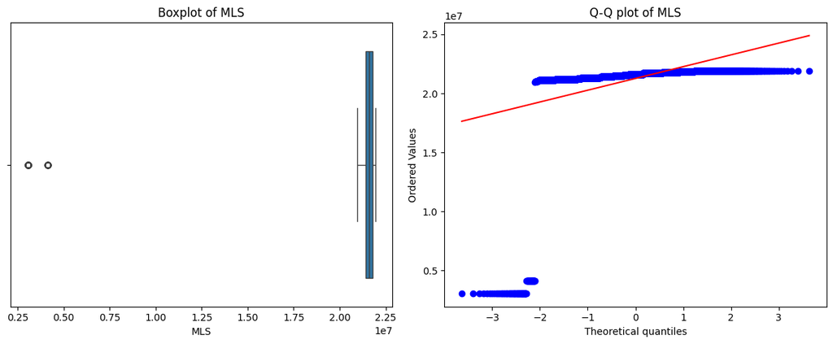

```
Outlier Analysis for sold_price
```

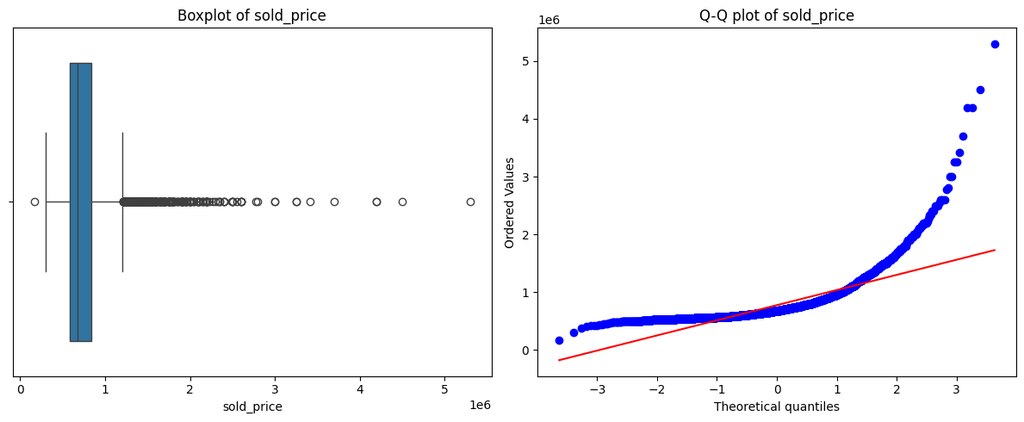

```
Outlier Analysis for zipcode
```

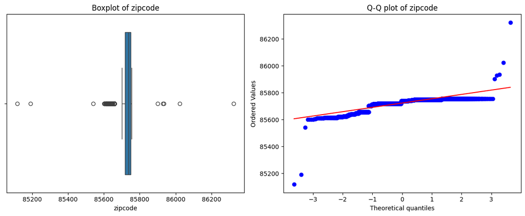

```
Outlier Analysis for longitude
```

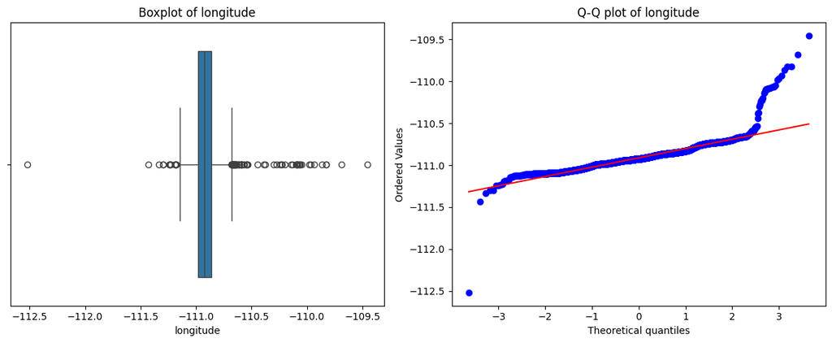

```
Outlier Analysis for latitude
```

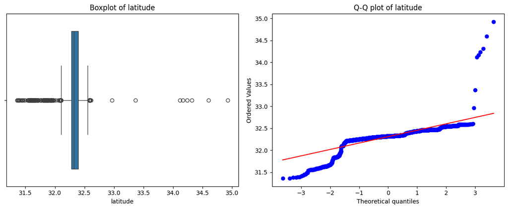

```
Outlier Analysis for lot_acres
```

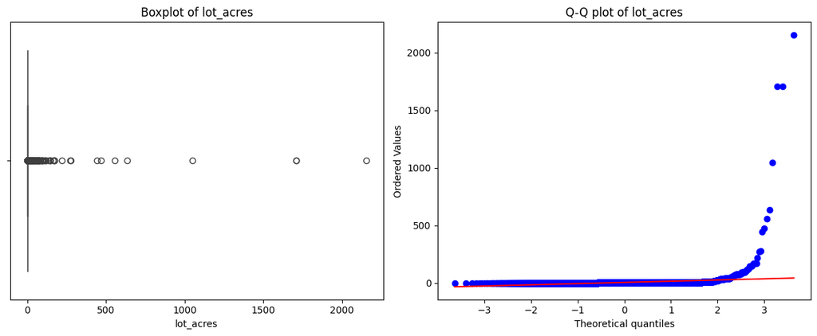

```
Outlier Analysis for taxes
```

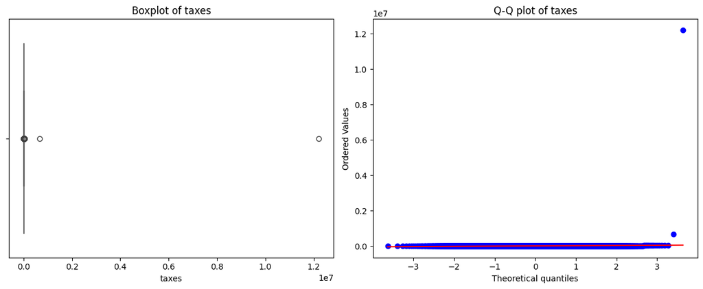

```
Outlier Analysis for year_built
```

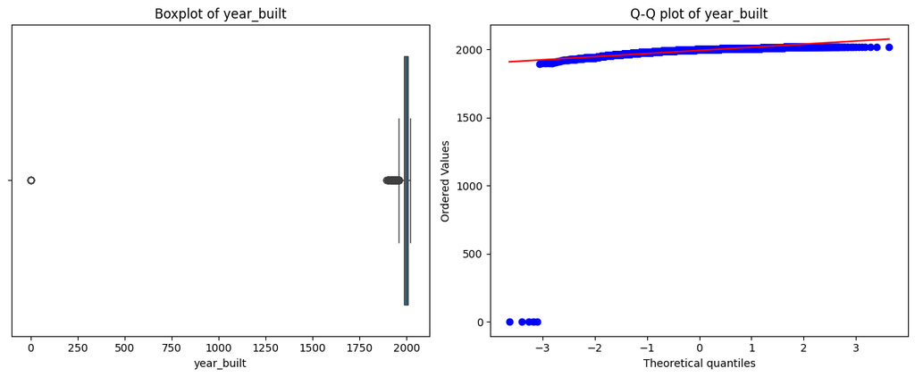

```
Outlier Analysis for bedrooms
```

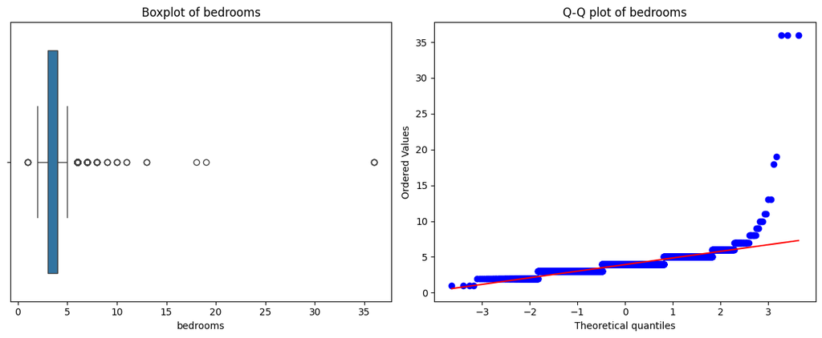

```
Outlier Analysis for bathrooms
```

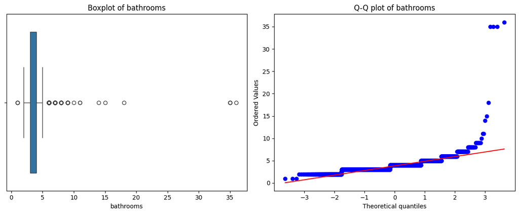

```
Outlier Analysis for sqrt_ft
```

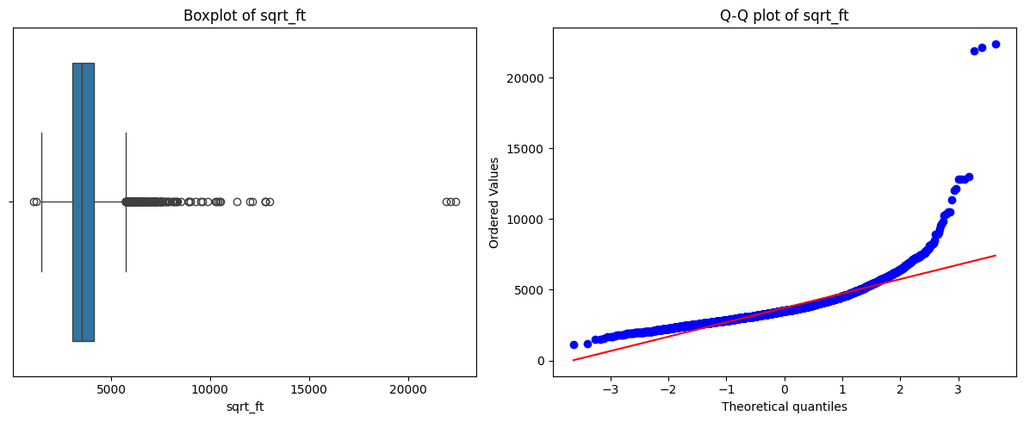

```
Outlier Analysis for garage
```

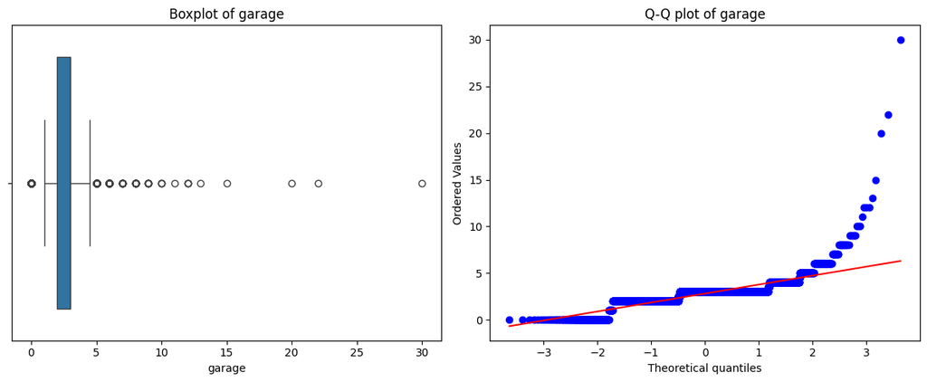

```
Outlier Analysis for fireplaces
```

[2 more figures not shown]

```python
from scipy import stats
for column in numeric_columns:
    print(f"Outlier Analysis for {column}")

    plt.figure(figsize=(12, 5))
    plt.subplot(121)
    sns.boxplot(x=df[column])
    plt.title(f'Boxplot of {column}')

    plt.subplot(122)
    stats.probplot(df[column], dist="norm", plot=plt)
    plt.title(f'Q-Q plot of {column}')
    plt.tight_layout()
    plt.show()
    print("\n")
```

**Outlier Detection Analysis** We use boxplots and Q-Q plots to visualize the distribution of numeric features and identify potential outliers.

**2. Patterns in the outliers:**

- Most features show right-skewed distributions with outliers primarily on the upper end.
- lot_acres and taxes seem to have the most extreme outliers, potentially indicating some very large or unique properties.
- Outliers in sold_price, sqrt_ft, and HOA are less extreme but still notable.

**3. Strategies for handling outliers:**

- Investigate extreme outliers (e.g., in lot_acres and taxes) to ensure they are not data entry errors.
- For genuine outliers, consider: Using robust statistical methods that are less sensitive to outliers.
- For modeling purposes, we might want to create separate models for luxury properties vs. standard properties.
- Consider the impact of removing outliers on the dataset size and representation of high-end properties.

**Correlation**

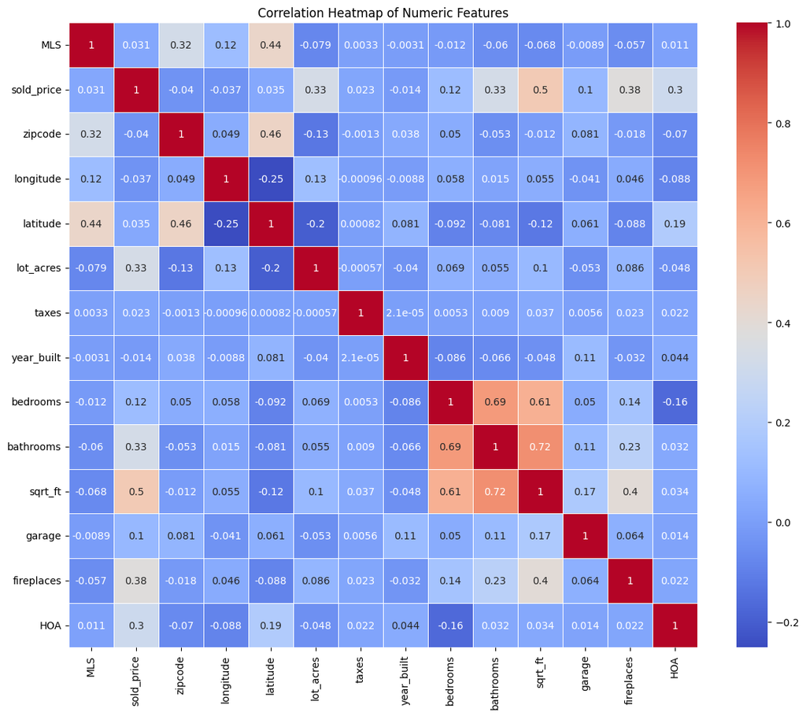

```python
# Create correlation matrix
correlation_matrix = df[numeric_columns].corr()

# Create correlation heatmap
plt.figure(figsize=(12, 10))
sns.heatmap(correlation_matrix, annot=True, cmap='coolwarm', linewidths=0.5)
plt.title('Correlation Heatmap of Numeric Features')
plt.tight_layout()
plt.show()
```

```python
# Create correlation table
correlation_table = correlation_matrix.round(2)
print("Correlation Table:")
print(correlation_table.to_string())
```

```
Correlation Table:
             MLS  sold_price  zipcode  longitude  latitude  lot_acres  taxes  year_built  bedrooms  bathrooms  sqrt_ft  garage  fireplaces   HOA
MLS         1.00        0.03     0.32       0.12      0.44      -0.08   0.00       -0.00     -0.01      -0.06    -0.07   -0.01       -0.06  0.01
sold_price  0.03        1.00    -0.04      -0.04      0.04       0.33   0.02       -0.01      0.12       0.33     0.50    0.10        0.38  0.30
zipcode     0.32       -0.04     1.00       0.05      0.46      -0.13  -0.00        0.04      0.05      -0.05    -0.01    0.08       -0.02 -0.07
longitude   0.12       -0.04     0.05       1.00     -0.25       0.13  -0.00       -0.01      0.06       0.01     0.05   -0.04        0.05 -0.09
latitude    0.44        0.04     0.46      -0.25      1.00      -0.20   0.00        0.08     -0.09      -0.08    -0.12    0.06       -0.09  0.19
lot_acres  -0.08        0.33    -0.13       0.13     -0.20       1.00  -0.00       -0.04      0.07       0.06     0.10   -0.05        0.09 -0.05
taxes       0.00        0.02    -0.00      -0.00      0.00      -0.00   1.00        0.00      0.01       0.01     0.04    0.01        0.02  0.02
year_built -0.00       -0.01     0.04      -0.01      0.08      -0.04   0.00        1.00     -0.09      -0.07    -0.05    0.11       -0.03  0.04
bedrooms   -0.01        0.12     0.05       0.06     -0.09       0.07   0.01       -0.09      1.00       0.69     0.61    0.05        0.14 -0.16
bathrooms  -0.06        0.33    -0.05       0.01     -0.08       0.06   0.01       -0.07      0.69       1.00     0.72    0.11        0.23  0.03
sqrt_ft    -0.07        0.50    -0.01       0.05     -0.12       0.10   0.04       -0.05      0.61       0.72     1.00    0.17        0.40  0.03
garage     -0.01        0.10     0.08      -0.04      0.06      -0.05   0.01        0.11      0.05       0.11     0.17    1.00        0.06  0.01
fireplaces -0.06        0.38    -0.02       0.05     -0.09       0.09   0.02       -0.03      0.14       0.23     0.40    0.06        1.00  0.02
HOA         0.01        0.30    -0.07      -0.09      0.19      -0.05   0.02        0.04     -0.16       0.03     0.03    0.01        0.02  1.00
```

**Coreelation Analysis**

Used a heatmap to visualize the correlations between numeric features.

**3. Unexpected correlations:**

- 'year_built' shows weak correlations with most features, including 'sold_price'. This suggests that the age of the house might not be a strong predictor of its price in this dataset.
- 'lot_acres' has a relatively weak correlation with 'sold_price', which is somewhat surprising. We might expect larger lots to be associated with higher prices.

**These observations will guide our feature selection and engineering process in the next steps of our analysis.**

```python
# Handle outliers (using IQR (Interquartile Range) method for numeric columns)
for column in numeric_columns:
    Q1 = df[column].quantile(0.25)   # Calculate the 25th percentile
    Q3 = df[column].quantile(0.75)   # Calculate the 75th percentile
    IQR = Q3 - Q1                    # Calculate the interquartile range
    lower_bound = Q1 - 1.5 * IQR
    upper_bound = Q3 + 1.5 * IQR
    df[column] = df[column].clip(lower_bound, upper_bound)

# Encode categorical variables
categorical_columns = df.select_dtypes(include=['object']).columns
df = pd.get_dummies(df, columns=categorical_columns, drop_first=True) # creates binary (0 or 1) for each category

# Feature scaling (without using sklearn)
# purpose the numerical features to have mean of (0) and standard deviation of (1) is mean/std = standardization
for column in numeric_columns:
    df[column] = (df[column] - df[column].mean()) / df[column].std()
```

```python
print(df.describe())
```

```
                MLS    sold_price       zipcode     longitude      latitude  \
count  5.000000e+03  5.000000e+03  5.000000e+03  5.000000e+03  5.000000e+03
mean  -3.623768e-16 -2.728484e-16  2.138549e-13  1.821093e-13  8.555503e-14
std    1.000000e+00  1.000000e+00  1.000000e+00  1.000000e+00  1.000000e+00
min   -3.074272e+00 -2.627188e+00 -2.120980e+00 -2.467970e+00 -2.293414e+00
25%   -6.795147e-01 -7.785029e-01 -3.337474e-01 -6.452360e-01 -4.929779e-01
50%    1.536587e-01 -3.348186e-01  3.965196e-01 -8.064347e-02 -7.148419e-02
75%    9.169904e-01  4.539536e-01  8.577409e-01  5.699202e-01  7.073127e-01
max    1.413912e+00  2.302638e+00  2.644973e+00  2.392654e+00  2.507749e+00

          lot_acres         taxes    year_built      bedrooms     bathrooms  \
count  5.000000e+03  5.000000e+03  5.000000e+03  5.000000e+03  5.000000e+03
mean   1.364242e-16  1.364242e-16  6.366463e-15 -1.932676e-16 -2.273737e-16
std    1.000000e+00  1.000000e+00  1.000000e+00  1.000000e+00  1.000000e+00
min   -1.242816e+00 -2.309642e+00 -2.400453e+00 -2.942328e+00 -2.579851e+00
25%   -7.187040e-01 -6.316799e-01 -5.318502e-01 -1.084563e+00 -8.555053e-01
50%   -3.482110e-01 -1.356011e-01  2.549298e-01  1.539468e-01  2.940584e-01
75%    3.385565e-01  5.137963e-01  7.138848e-01  1.539468e-01  2.940584e-01
max    1.924447e+00  2.232011e+00  1.566230e+00  2.011712e+00  2.018404e+00

            sqrt_ft        garage    fireplaces           HOA
count  5.000000e+03  5.000000e+03  5.000000e+03  5.000000e+03
mean   2.273737e-16 -7.958079e-17 -2.273737e-17  6.821210e-17
std    1.000000e+00  1.000000e+00  1.000000e+00  1.000000e+00
min   -2.537609e+00 -2.841222e+00 -1.682848e+00 -9.048186e-01
25%   -6.940150e-01 -9.566227e-01 -7.888575e-01 -9.048186e-01
50%   -1.726638e-01  2.997770e-01  1.051333e-01 -3.384447e-01
75%    5.350477e-01  2.997770e-01  9.991242e-01  6.655817e-01
max    2.378642e+00  2.184376e+00  3.681097e+00  3.021182e+00
```

**Data Cleaning and Transformation**

Based on the observations, below are the following cleaning and transformation steps:

**Justification**:

1. **Median** and **mode** imputation preserves the overall **distribution** of the **data**
2. **IQR method** for **outlier handlin**g is robust and doesn't assume a specific distribution
3. **One-hot encoding** is suitable for **nominal categorical variables**
4. **Standardization** transforms data to have a **mean of 0 and a standard deviation of 1.**

**Visualise the Transformed data**

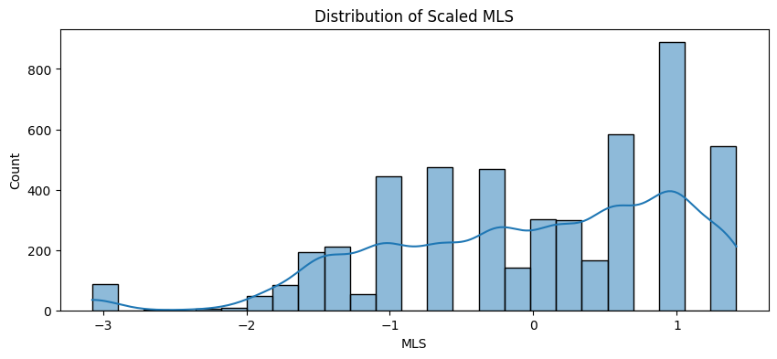

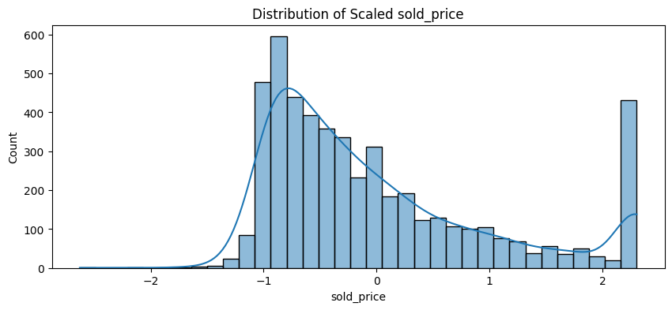

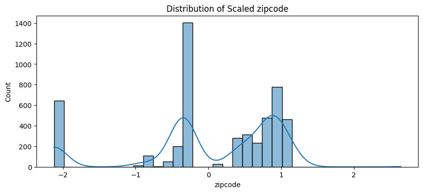

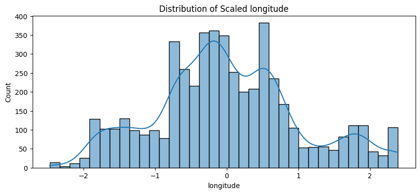

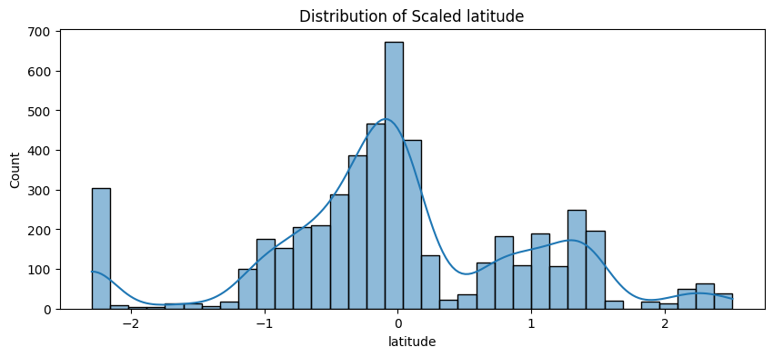

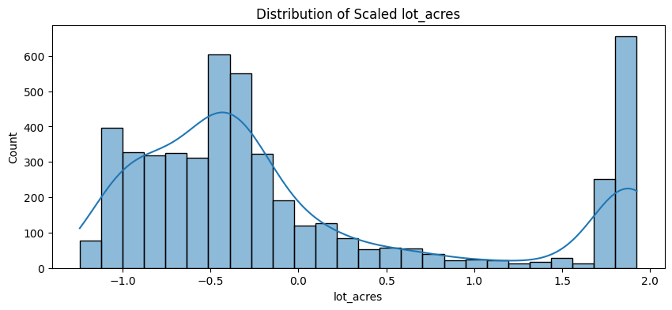

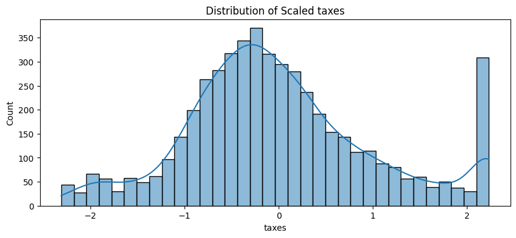

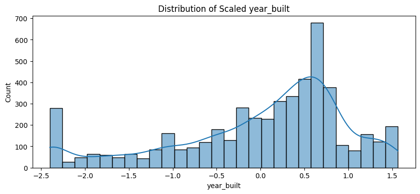

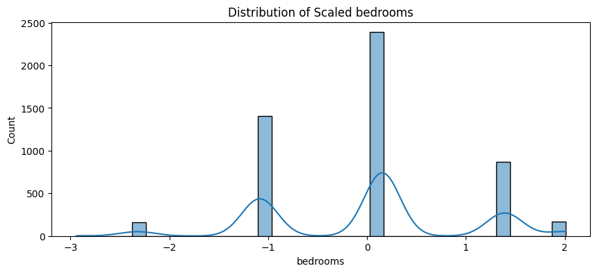

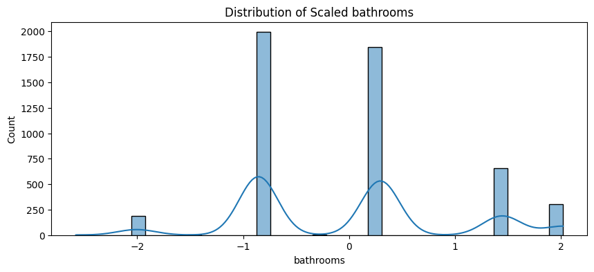

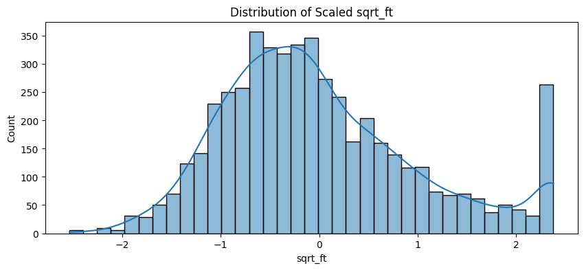

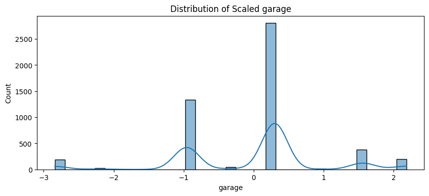

[2 more figures not shown]

```python
for column in numeric_columns:
    plt.figure(figsize=(10, 4))
    sns.histplot(df[column], kde=True)
    plt.title(f'Distribution of Scaled {column}')
    plt.show()
```

```python
# Save the cleaned dataset
cleaned_dataset.to_csv('cleaned_dataset.csv', index=False)
```

**MACHINE LEARNING**

```python
# Cleaned Dataset from data analyst
df = cleaned_dataset
df.head()
```

|  | MLS | sold_price | zipcode | longitude | latitude | lot_acres | taxes | year_built | bedrooms | bathrooms | sqrt_ft | garage | fireplaces | HOA |
| --- | --- | --- | --- | --- | --- | --- | --- | --- | --- | --- | --- | --- | --- | --- |
| 0 | 21530491 | 5300000.0 | 85637 | -110.378200 | 31.356362 | 2154.00 | 5272.00 | 1941 | 13 | 10.0 | 10500.00000 | 0.0 | 6.0 | 0.0 |
| 1 | 21529082 | 4200000.0 | 85646 | -111.045371 | 31.594213 | 1707.00 | 10422.36 | 1997 | 2 | 2.0 | 7300.00000 | 0.0 | 5.0 | 0.0 |
| 2 | 3054672 | 4200000.0 | 85646 | -111.040707 | 31.594844 | 1707.00 | 10482.00 | 1997 | 2 | 3.0 | 2678.59434 | 3.0 | 5.0 | 0.0 |
| 3 | 21919321 | 4500000.0 | 85646 | -111.035925 | 31.645878 | 636.67 | 8418.58 | 1930 | 7 | 5.0 | 9019.00000 | 4.0 | 4.0 | 0.0 |
| 4 | 21306357 | 3411450.0 | 85750 | -110.813768 | 32.285162 | 3.21 | 15393.00 | 1995 | 4 | 6.0 | 6396.00000 | 3.0 | 5.0 | 55.0 |

```python
# Checking null values
df.isnull().sum()
```

|  | 0 |
| --- | --- |
| MLS | 0 |
| sold_price | 0 |
| zipcode | 0 |
| longitude | 0 |
| latitude | 0 |
| lot_acres | 0 |
| taxes | 0 |
| year_built | 0 |
| bedrooms | 0 |
| bathrooms | 0 |
| sqrt_ft | 0 |
| garage | 0 |
| fireplaces | 0 |
| HOA | 0 |

**dtype:** int64

```python
# Libraries
import pandas as pd
import numpy as np
import matplotlib.pyplot as plt
import seaborn as sns
```

```python
# Calculate price per square foot
df['price_per_sqft'] = df['sold_price'] / df['sqrt_ft']
```

```python
# Summary Statistics of Price per Square Foot
average_price_per_sqft = df['price_per_sqft'].mean()
min_price_per_sqft = df['price_per_sqft'].min()
max_price_per_sqft = df['price_per_sqft'].max()
median_price_per_sqft = df['price_per_sqft'].median()
# Print the results
print(f"Average Price per Sqft: ${average_price_per_sqft:.2f}")
print(f"Minimum Price per Sqft: ${min_price_per_sqft:.2f}")
print(f"Maximum Price per Sqft: ${max_price_per_sqft:.2f}")
print(f"Median Price per Sqft: ${median_price_per_sqft:.2f}")
```

```
Average Price per Sqft: $212.37
Minimum Price per Sqft: $24.54
Maximum Price per Sqft: $1567.99
Median Price per Sqft: $202.10
```

```python
# Create 20 price per sqft categories (bins)
df['price_category'] = pd.qcut(df['price_per_sqft'], 20, labels=False)
```

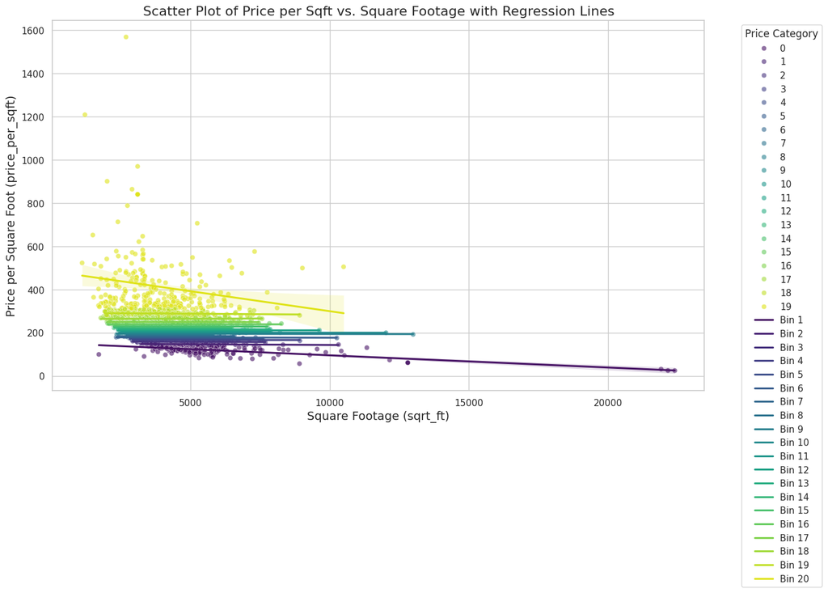

```python
# Scatter plot
sns.set(style='whitegrid')
palette = sns.color_palette('viridis', n_colors=20)
plt.figure(figsize=(14, 8))
sns.scatterplot(data=df, x='sqrt_ft', y='price_per_sqft', hue='price_category', palette=palette, alpha=0.6)

for i in range(20):
    sns.regplot(data=df[df['price_category'] == i],
                x='sqrt_ft',
                y='price_per_sqft',
                scatter=False,
                color=palette[i],
                label=f'Bin {i+1}')

plt.title('Scatter Plot of Price per Sqft vs. Square Footage with Regression Lines', fontsize=16)
plt.xlabel('Square Footage (sqrt_ft)', fontsize=14)
plt.ylabel('Price per Square Foot (price_per_sqft)', fontsize=14)
plt.legend(title='Price Category', bbox_to_anchor=(1.05, 1), loc='upper left')
plt.show()
```

```python
# price category statistics
print("\nPrice per Square Foot Statistics by Category:")
print(df.groupby('price_category')['price_per_sqft'].describe())
```

```
Price per Square Foot Statistics by Category:
                count        mean         std         min         25%  \
price_category
0               250.0  121.371818   18.867256   24.544805  116.353979
1               250.0  147.008981    4.095736  139.181573  143.783275
2               250.0  157.827185    2.459756  153.470308  155.792547
3               250.0  165.891929    2.056620  162.092068  164.185231
4               250.0  172.565854    1.737067  169.328194  171.075996
5               250.0  178.098246    1.549864  175.385546  176.894025
6               250.0  183.470801    1.702754  180.714916  181.867218
7               250.0  188.996974    1.415644  186.522262  187.813356
8               250.0  194.613958    1.729088  191.627212  193.021334
9               250.0  199.955297    1.329108  197.451086  198.905301
10              250.0  204.935411    1.622736  202.102458  203.499248
11              250.0  210.175144    1.530922  207.744488  208.890681
```

[output cut: 31 more lines]

```python
# price range for each category
category_ranges = df.groupby('price_category')['price_per_sqft'].agg(['min', 'max'])
print("\nPrice Range for Each Category:")
for category in category_ranges.index:
    print(f"\nCategory {category}:")
    print(f"Min: ${category_ranges.loc[category, 'min']:.2f} per sqft")
    print(f"Max: ${category_ranges.loc[category, 'max']:.2f} per sqft")
```

```
Price Range for Each Category:

Category 0:
Min: $24.54 per sqft
Max: $139.05 per sqft

Category 1:
Min: $139.18 per sqft
Max: $153.44 per sqft

Category 2:
Min: $153.47 per sqft
Max: $162.06 per sqft

Category 3:
Min: $162.09 per sqft
Max: $169.33 per sqft

Category 4:
Min: $169.33 per sqft
Max: $175.38 per sqft

Category 5:
Min: $175.39 per sqft
Max: $180.71 per sqft

Category 6:
Min: $180.71 per sqft
Max: $186.48 per sqft

Category 7:
Min: $186.52 per sqft
Max: $191.61 per sqft

Category 8:
Min: $191.63 per sqft
Max: $197.39 per sqft

Category 9:
Min: $197.45 per sqft
```

[output cut: 26 more lines]

```
Category 16:
Min: $242.90 per sqft
Max: $255.30 per sqft

Category 17:
Min: $255.38 per sqft
Max: $275.25 per sqft

Category 18:
Min: $275.27 per sqft
Max: $309.00 per sqft

Category 19:
Min: $309.28 per sqft
Max: $1567.99 per sqft
```

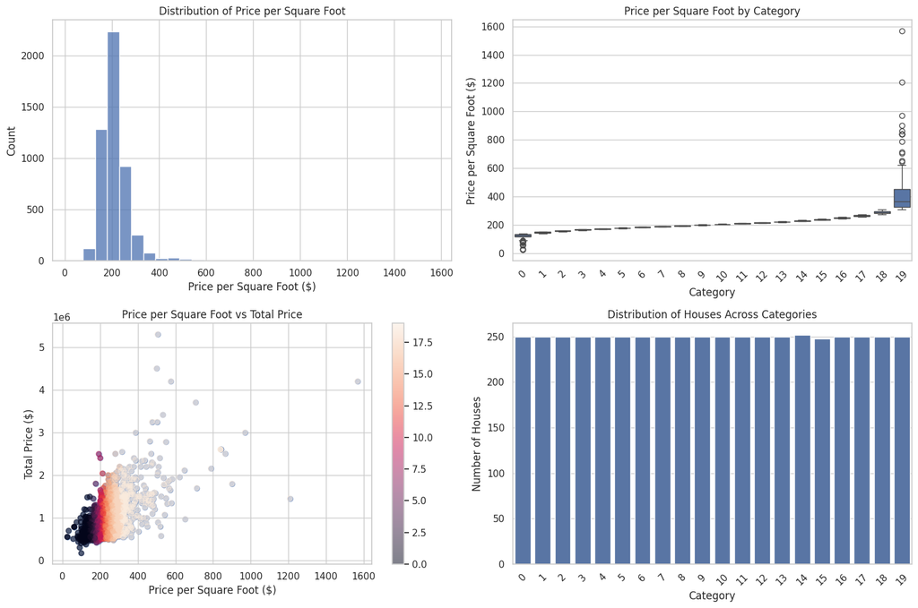

```python
# Plots
fig = plt.figure(figsize=(15, 10))
plt.subplot(2, 2, 1)
sns.histplot(data=df, x='price_per_sqft', bins=30)
plt.title('Distribution of Price per Square Foot')
plt.xlabel('Price per Square Foot ($)')
plt.ylabel('Count')

plt.subplot(2, 2, 2)
sns.boxplot(data=df, x='price_category', y='price_per_sqft')
plt.title('Price per Square Foot by Category')
plt.xlabel('Category')
plt.ylabel('Price per Square Foot ($)')
plt.xticks(rotation=45)

plt.subplot(2, 2, 3)
plt.scatter(df['price_per_sqft'], df['sold_price'], alpha=0.5)
plt.colorbar(plt.scatter(df['price_per_sqft'], df['sold_price'],
                        c=df['price_category'], alpha=0.5))
plt.title('Price per Square Foot vs Total Price')
plt.xlabel('Price per Square Foot ($)')
plt.ylabel('Total Price ($)')

plt.subplot(2, 2, 4)
category_counts = df['price_category'].value_counts().sort_index()
sns.barplot(x=category_counts.index, y=category_counts.values)
plt.title('Distribution of Houses Across Categories')
plt.xlabel('Category')
plt.ylabel('Number of Houses')
plt.xticks(rotation=45)

plt.tight_layout()
plt.show()
```

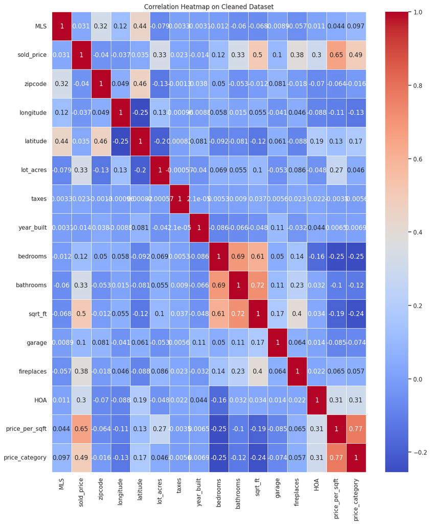

```python
# Correlation
correlation_matrix_cleaned_dataset = df.corr()

# Create correlation heatmap
plt.figure(figsize=(12, 14))
sns.heatmap(correlation_matrix_cleaned_dataset, annot=True, cmap='coolwarm', linewidths=0.5)
plt.title('Correlation Heatmap on Cleaned Dataset')
plt.tight_layout()
plt.show()
```

# KNN

```python
# Extract spatial features for KNN
X_spatial = df[['latitude', 'longitude']].copy().to_numpy()  # KNN feature matrix (lat, lon)
print("Spatial Features for KNN:", X_spatial)
```

```
Spatial Features for KNN: [[  31.356362 -110.3782  ]
 [  31.594213 -111.045371]
 [  31.594844 -111.040707]
 ...
 [  32.964708 -110.755428]
 [  32.296871 -111.055528]
 [  31.385259 -110.913054]]
```

```python
y_knn = df['price_category'].copy().to_numpy()  # Target variable for KNN
print("Target Variable for KNN:" , y_knn)
```

```
Target Variable for KNN: [19 19 19 ... 17  1  0]
```

```python
# KNN function without sklearn

class KNNClassifier:
    def fit(self, X, y):
        self.X_train = X
        self.y_train = y

    def predict(self, X, K=3, epsilon=1e-3):
        N = len(X)
        y_pred = np.zeros(N)

        for i in range(N):
            dist2 = np.sum((self.X_train - X[i]) ** 2, axis=1)
            nearest_neighbors_idx = np.argsort(dist2)[:K]
            weights = 1 / (np.sqrt(dist2[nearest_neighbors_idx] + epsilon))
            y_pred[i] = np.bincount(self.y_train[nearest_neighbors_idx], weights=weights).argmax()

        return y_pred

knn = KNNClassifier()

knn.fit(X_spatial, y_knn)

y_pred_knn = knn.predict(X_spatial, K=3)
df['knn_price_category'] = y_pred_knn   # knn weights will use this to predict price

# Calculate accuracy
accuracy = np.mean(y_pred_knn == y_knn)
print(f'Accuracy: {accuracy * 100:.2f}%')
```

```
Accuracy: 90.42%
```

```
Length of X_spatial: 5000
Length of y_knn: 5000
```

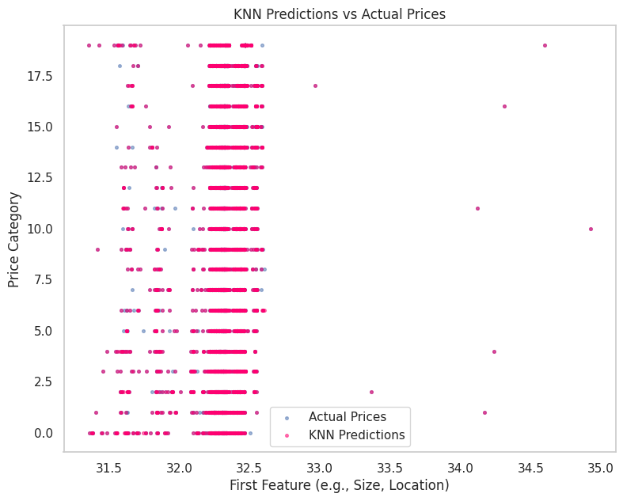

```python
import matplotlib.pyplot as plt

# Ensure the lengths match
print(f"Length of X_spatial: {len(X_spatial)}")
print(f"Length of y_knn: {len(y_knn)}")

# Assuming X_spatial is 2D and we want to use the first feature for plotting
plt.figure(figsize=(9, 7))
plt.scatter(X_spatial[:, 0], y_knn, s=7, label='Actual Prices', alpha=0.5)  # Plot actual prices
plt.scatter(X_spatial[:, 0], y_pred_knn, s=7, color='#FF0070', label='KNN Predictions', alpha=0.5)  # Plot KNN predictions
plt.title('KNN Predictions vs Actual Prices')
plt.xlabel('First Feature (e.g., Size, Location)')
plt.ylabel('Price Category')
plt.legend()
plt.grid()
plt.show()
```

**Interpretation**